# SDS/CSC 293 Mini-Project 1: Splines

Wednesday, February 13<sup>th</sup>, 2019

You will be submiting an entry to Kaggle’s [House Prices: Advanced Regression Techniques](https://www.kaggle.com/c/house-prices-advanced-regression-techniques/) by fitting a **spline** model $\hat{f}(x)$ using a single numerical predictor $x$ of your choice. Note that splines are not a great model to use in practice since they only allow you to use one predictor variable at a time, however they are an excellent vehicle for thinking about the ideas behind crossvalidation.

# Data

Read in data provided by Kaggle for this competition. They are organized in the `data/` folder of this RStudio project:

```r
training <- read_csv("data/train.csv")
test <- read_csv("data/test.csv")
sample_submission <- read_csv("data/sample_submission.csv")
```

Before performing any model fitting, you should always conduct an **exploratory data analysis** (EDA). This will help guide and inform your model fitting.

## Look at your data!

Always, ALWAYS, **ALWAYS** start by looking at your raw data. This gives you visual sense of what information you have to help build your predictive models. To get a full description of each variable, read the data dictionary in the `data_description.txt` file in the `data/` folder.

Note that the following code chunk has `eval = FALSE` meaning “don’t evaluate this chunk with knitting” because `.Rmd` files won’t knit if they include a `View()`:

```r
View(training)
glimpse(training)

View(test)
glimpse(test)
```

In particular, pay close attention to the variables and variable types in the `sample_submission.csv`. Your submission must match this exactly.

```r
glimpse(sample_submission)
```

```
## Observations: 1,459
## Variables: 2
## $ Id        <int> 1461, 1462, 1463, 1464, 1465, 1466, 1467, 1468, 1469, …
## $ SalePrice <dbl> 169277.1, 187758.4, 183583.7, 179317.5, 150730.1, 1771…
```

## Data wrangling

Do any data wrangling/transforming here:

I’m going to use `GrLivArea`

```r
training <- training %>%
  select(Id, GrLivArea, SalePrice)
test <- test %>%
  select(Id, GrLivArea)
```

## Visualizations

A univariate exploratory visualization of the outcome variable:

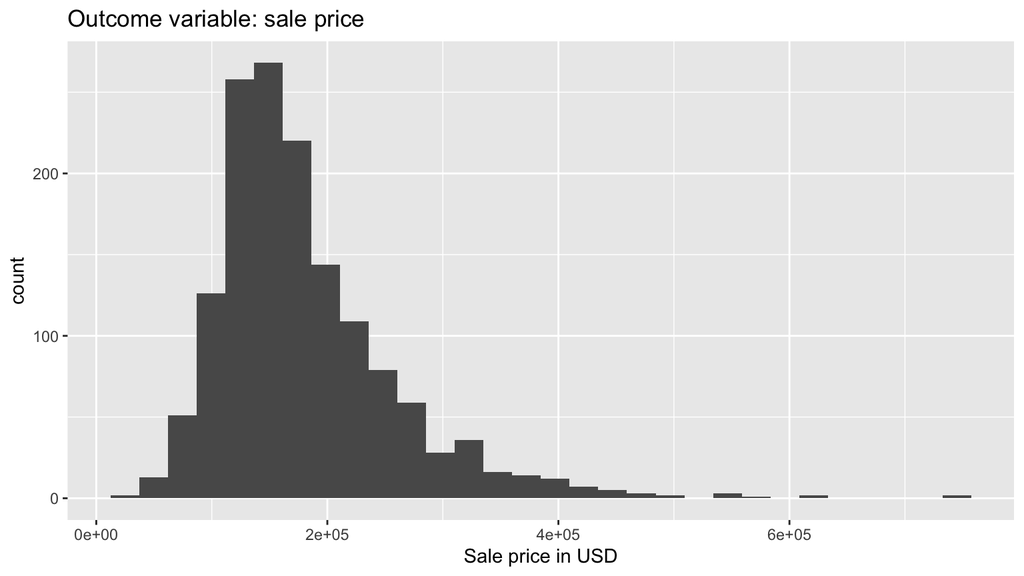

```r
ggplot(training, aes(x = SalePrice)) +
  geom_histogram() +
  labs(x = "Sale price in USD", title = "Outcome variable: sale price")
```

Given that the outcome variable:

1. Is Very skewed
2. Has to be greater than 0

I will:

1. Create a temporary outcome variable `log10_SalePrice` by running `log10(SalePrice)`. So a house that is one million dollars = 10<sup>6</sup> will be 6.
2. Do all model fitting and predictions.
3. Return to the original outcome variable by “un-log10” the data

```r
training <- training %>%
  mutate(log10_SalePrice = log10(SalePrice))
```

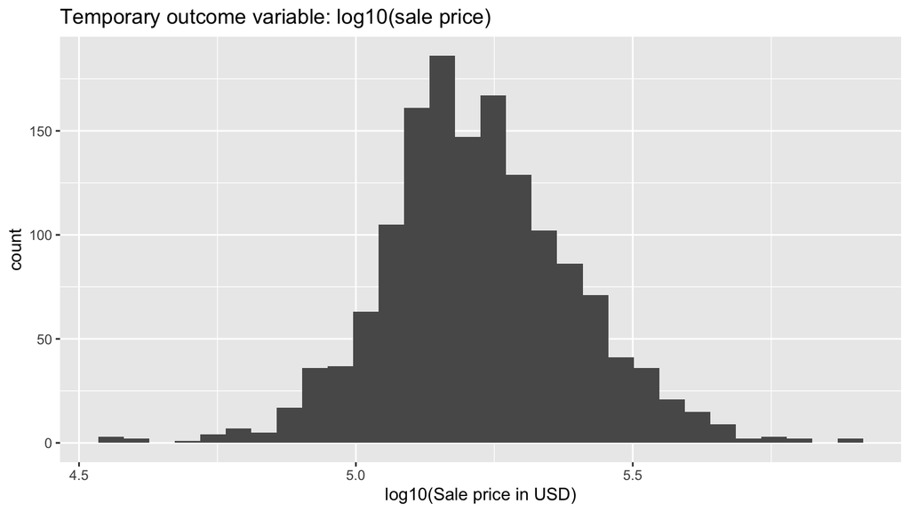

```r
ggplot(training, aes(x = log10_SalePrice)) +
  geom_histogram() +
  labs(x = "log10(Sale price in USD)", title = "Temporary outcome variable: log10(sale price)")
```

A univariate exploratory visualization of the predictor variable:

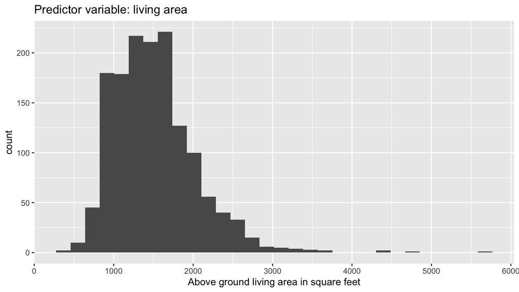

```r
ggplot(training, aes(x = GrLivArea)) +
  geom_histogram() +
  labs(x = "Above ground living area in square feet", title = "Predictor variable: living area")
```

```r
training <- training %>%
  mutate(log10_GrLivArea = log10(GrLivArea))
test <- test %>%
  mutate(log10_GrLivArea = log10(GrLivArea))
```

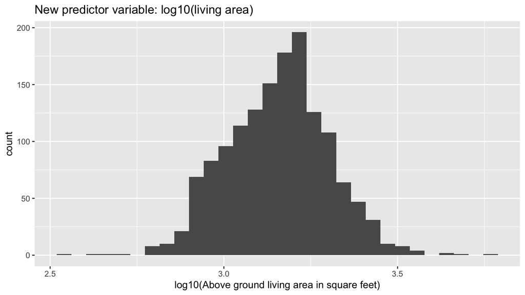

```r
ggplot(training, aes(x = log10_GrLivArea)) +
  geom_histogram() +
  labs(x = "log10(Above ground living area in square feet)", title = "New predictor variable: log10(living area)")
```

A multivariate exploratory visualization of the *relationship* between the outcome and predictor variable.

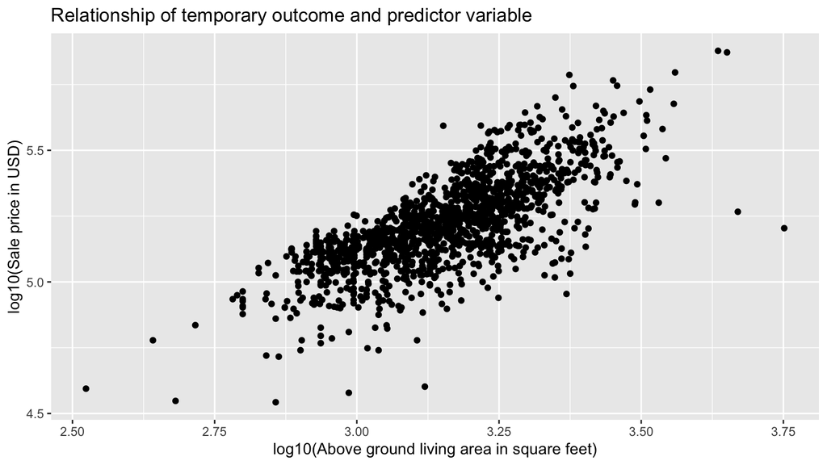

```r
ggplot(training, aes(x = log10_GrLivArea, y = log10_SalePrice)) +
  geom_point() +
  labs(x = "log10(Above ground living area in square feet)",
       y = "log10(Sale price in USD)",
       title = "Relationship of temporary outcome and predictor variable")
```

# Explore choices of df

This whole section relates to the **due diligence** and the **reaching for the stars** steps of the grading scheme: choosing the degrees of freedom $df$ in a non-arbitrary fashion.

## Crossvalidation from scratch

Implement crossvalidation from scratch here. In other words, don’t use an existing function, but rather program your own.

```r
training <- training %>%
  sample_frac(1) %>%
  mutate(fold = rep(1:5, length = n())) %>%
  arrange(fold)

df_RMLSE <- tibble(
  df = c(2:50),
  RMLSE = 0
)

for(i in 1:nrow(df_RMLSE)){
  df <- df_RMLSE$df[i]

  RMLSE <- rep(0, 5)
  for(j in 1:5){
    pretend_training <- training %>%
      filter(fold != j)
    pretend_test <- training %>%
      filter(fold == j)

    # Fit model on pretend training
    fitted_spline_model <-
      smooth.spline(x = pretend_training$log10_GrLivArea,
                    y = pretend_training$log10_SalePrice, df = df)

    # Make predictions
    predicted_points <- predict(fitted_spline_model, x = pretend_test$log10_GrLivArea) %>%
      as_tibble()

    # Save predictions in pretend_test data frame
    pretend_test <- pretend_test %>%
      mutate(
        log10_SalePrice_hat = predicted_points$y,
        SalePrice_hat = 10^log10_SalePrice_hat
      )

    RMLSE[j] <- pretend_test %>%
      mutate(
        residual = log(SalePrice + 1) - log(SalePrice_hat + 1),
        residual_sq = residual^2
      ) %>%
      summarize(
        MLSE = mean(residual_sq),
        RMLSE = sqrt(MLSE)
      ) %>%
      pull(RMLSE)
  }

  df_RMLSE$RMLSE[i] <- mean(RMLSE)
}
```

## Visualization justifying your choice of “optimal” df

This subsection relates to the **point of diminishing returns** step of the grading scheme: a visualization like [Lec01 slides #36](http://rudeboybert.rbind.io/talk/2019-01-13-Williams.pdf#page=36) justifying your choice of optimal `df^*`.

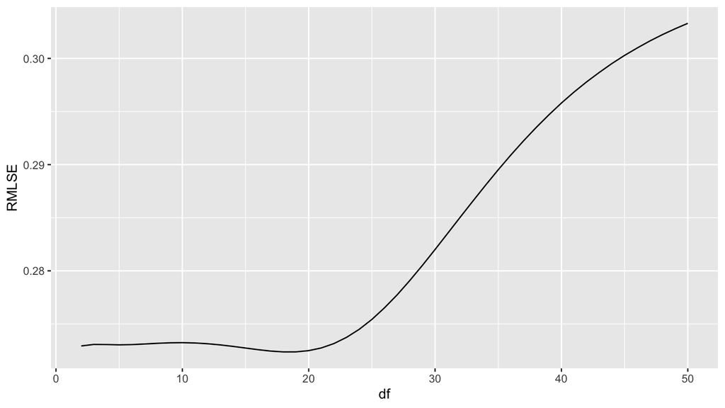

```r
ggplot(df_RMLSE, aes(x = df, y = RMLSE)) +
  geom_line()
```

# Make predictions based on chosen df

Set `df_star` to be the degrees of freedom you’ll use to make your predictions, arbitrarily chosen or not.

```r
df_RMLSE <- df_RMLSE %>%
  arrange(RMLSE)

df_RMLSE %>%
  slice(1)
```

| df | RMLSE |
| --- | --- |
| 18 | 0.2723672 |

```r
df_star <- df_RMLSE %>%
  slice(1) %>%
  pull(df)
```

## Visualize your model on training data

Visualize your fitted splines model $\widehat{f}()$ with degrees of freedom `df_star` on the training data. Recall we can only create this plot for the training data because we only have the outcome variable $y$ for the training data.

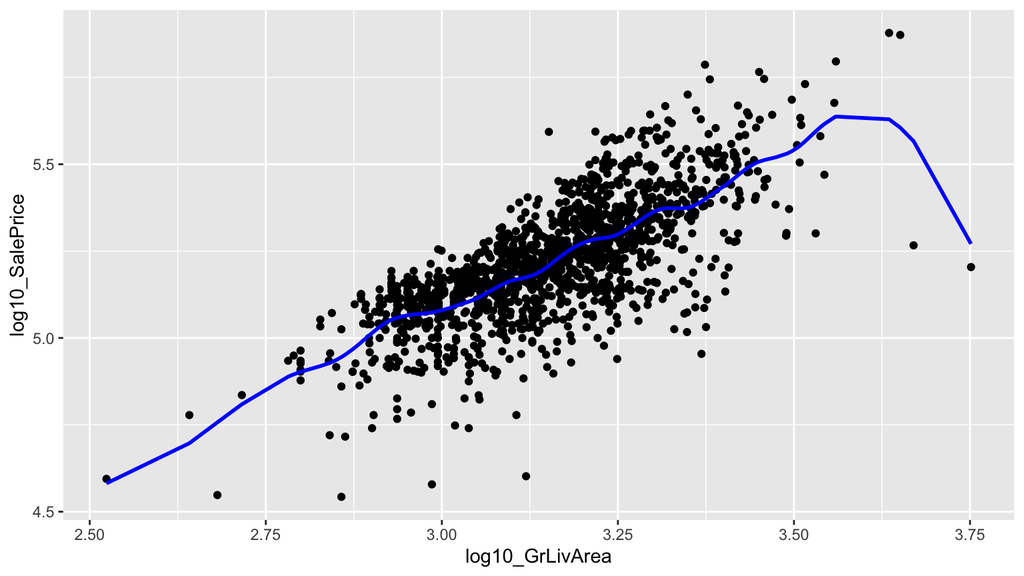

```r
# Fit model on pretend training
fitted_spline_model <-
  smooth.spline(x = training$log10_GrLivArea, y = training$log10_SalePrice, df = df_star)

# Make predictions
predicted_points <- predict(fitted_spline_model, x = training$log10_GrLivArea) %>%
  as_tibble()

# Save predictions in training data frame
training <- training %>%
  mutate(
    log10_SalePrice_hat = predicted_points$y,
    SalePrice_hat = 10^log10_SalePrice_hat
  )

ggplot(training, aes(x = log10_GrLivArea, y = log10_SalePrice)) +
  geom_point() +
  geom_line(aes(y = log10_SalePrice_hat), col = "blue", size = 1)
```

## Make predictions on test data

Make your predictions/get your predicted values $\widehat{y}$ on the test data.

```r
predicted_points <- predict(fitted_spline_model, x = test$GrLivArea) %>%
  as_tibble()

# Save predictions in pretend_test data frame
test <- test %>%
  mutate(
    log10_SalePrice_hat = predicted_points$y,
    SalePrice_hat = 10^log10_SalePrice_hat
  )
```

# Submission

## Create your submission CSV

```r
submission <- sample_submission %>%
  mutate(SalePrice = test$SalePrice_hat)

write_csv(submission, path = "data/submission_albert.csv")
```

## Screenshot of your Kaggle score

The “Root Mean Squared Logarithmic Error” score based on my example submission was 0.28782. Replace `score_screenshot.png` with a screenshot of your score.

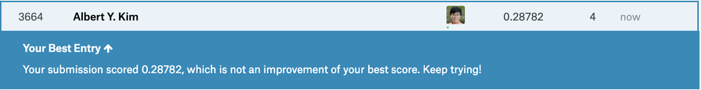

## Comparing your estimated score to your Kaggle score

This section relates to the **reaching for the stars** step of the grading scheme: showing that your estimated $\widehat{\text{RMLSE}}$ you obtained from your implemented crossvalidation scheme is “close” to the real $\text{RMLSE}$ that Kaggle returns on the leaderboard.

```r
df_RMLSE %>%
  slice(1)
```

| df | RMLSE |
| --- | --- |
| 18 | 0.2723672 |